# SBC on the GBM dataset from the whole Firebrowse Database(TCGA).

Karnofsky score corrected results

Camila Duitama (Based on Ashar Ahmad’s code for the SBC model)

May 2019

# 1 Loading of libraries

Libraries needed to run the code must be loaded first

# 2 Loading/Splitting training and testing sets

Data is separated into training and testing

```r
print(paste0("Number of patients in training set: ",as.character(n)))
```

```
[1] "Number of patients in training set: 160"
```

```r
print(paste0("Number of patients in test set: ",as.character(n.new)))
```

```
[1] "Number of patients in test set: 261"
```

## 2.1 Data visualization

Initial visualization of censoring, survival times and mRNAArray Data of the training and testing set

```r
table(censoring) %>%
  kable(caption = "Censoring frequency for the training set") %>%
  kable_styling(bootstrap_options = c("striped", "hover","responsive"),full_width = T, position = "center")
```

Censoring frequency for the training set

| censoring | Freq |
| --- | --- |
| 0 | 6 |
| 1 | 154 |

```r
table(censoring.new) %>%
  kable(caption = "Censoring frequency for the testing set") %>%
  kable_styling(bootstrap_options = c("striped", "hover", "condensed","responsive"),full_width = T, position = "center")
```

Censoring frequency for the testing set

| censoring.new | Freq |
| --- | --- |
| 0 | 48 |
| 1 | 213 |

```r
  Y.pre.train[1:5,1:5] %>%
  kable(caption = "mRNA MicroArray data for the Training set " ) %>%
  kable_styling(bootstrap_options = c("striped", "hover", "condensed","responsive"),full_width = T, position = "center")
```

mRNA MicroArray data for the Training set

| AACS | FSTL1 | ELMO2 | CREB3L1 | RPS11 |
| --- | --- | --- | --- | --- |
| 6.539245 | 9.794400 | 6.213981 | 4.836276 | 10.81124 |
| 7.186891 | 4.945053 | 5.230444 | 5.818606 | 10.47730 |
| 7.675038 | 10.840095 | 6.620676 | 5.333213 | 10.63727 |
| 7.996010 | 8.931571 | 7.552416 | 6.087341 | 11.00153 |
| 8.355122 | 4.240622 | 6.707334 | 4.865492 | 10.68588 |

```r
  Y.pre.test[1:5,1:5] %>%
  kable(caption = "mRNA MicroArray data for the Testing set " ) %>%
  kable_styling(bootstrap_options = c("striped", "hover", "condensed","responsive"),full_width = F, position = "center")
```

mRNA MicroArray data for the Testing set

| AACS | FSTL1 | ELMO2 | CREB3L1 | RPS11 |
| --- | --- | --- | --- | --- |
| 7.932201 | 9.225823 | 8.074686 | 5.634312 | 10.67623 |
| 7.766685 | 9.685415 | 7.801031 | 5.369319 | 10.73325 |
| 7.770307 | 8.995151 | 8.133011 | 4.882027 | 10.81575 |
| 6.995760 | 10.257413 | 7.011621 | 4.916572 | 10.79881 |
| 6.382742 | 9.717160 | 7.798868 | 5.852971 | 10.88847 |

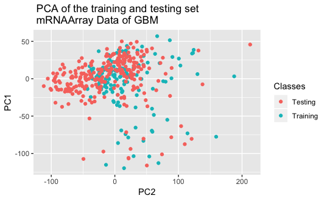

# 3 Signature calculation

This chunk calculates SBC gene signature It’s based on the idea of Univariate testing of Survival Data features **NOTE:** For now the rows where there is no censoring and time data will be removed from ALL datasets, until we find an imputation method.

## 3.1 PCA of the signature genes

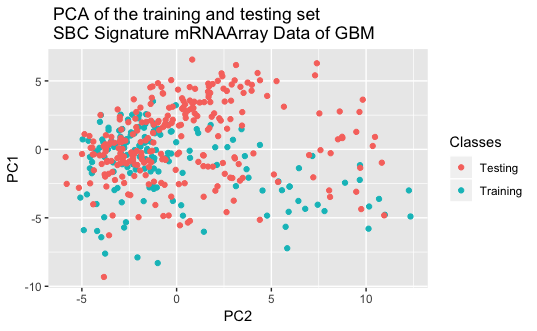

```r
mRNA.signature<-rbind(Y.pre.train[,signature.sbc],Y.pre.test[,signature.sbc])
mRNA.signature.pca<-as.data.frame(prcomp(mRNA.signature,scale=TRUE, center= TRUE)$x[,1:2])
mRNA.signature.pca$Classes<-classes
p6 <- ggplot(mRNA.signature.pca, aes(x=PC1, y=PC2, colour=Classes)) + ggtitle(" PCA of the training and testing set \n SBC Signature mRNAArray Data of GBM") + geom_point(shape=19) + labs(y = "PC1", x = "PC2", colour = "Classes")
p6
```

## 3.2 Survival curves for both training and testing set

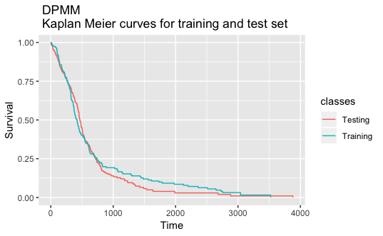

```r
surv.fit <- survfit(Surv(total_time,append(Clinical_TrainingSet$vital_status,Clinical_TestSet$vital_status))~ classes)
p3 <- ggsurv(surv.fit, plot.cens=FALSE,main = " DPMM \n Kaplan Meier curves for training and test set")+ ggplot2::guides(linetype = FALSE)
p3
```

# 4 Training

## 4.1 Preparation of the data needed for the training of the model

## 4.2 Training results

```r
print(paste0("Time (hours) necessary for burnin :",as.character(round(sum(burnintime)/3600),digits=5)))
```

```
[1] "Time (hours) necessary for burnin :1"
```

```r
print(paste0("Time (hours) necessary for Gibb's sampling :",as.character(round(sum(gibbstime/3600),digits=5))))
```

```
[1] "Time (hours) necessary for Gibb's sampling :0.63098"
```

## 4.3 Plots of results from training

```r
###############################
### Some plots and analysis ####
#################################
#### Generating some plots and results ON Training data ###
logrank <- survdiff(smod ~ c.final)
pval<-1 - pchisq(unlist(logrank)$chisq,df =3)
surv.fit <- survfit(smod ~ c.final)
p4 <- ggsurv(surv.fit,surv.col=c("#b16ed3","#d37f6e","#90d36e","#6ec2d3"),plot.cens=FALSE,main = " DPMM \n Kaplan Meier Estimators \n Training Set")+ ggplot2::guides(linetype = FALSE)+labs(subtitle = paste("P-value:",toString(round(pval,digits = 10))))
p4
```

[output not shown]

```r
############ Generating some Plots ##########################
pc <- prcomp(Y)
pc.pred <- predict(pc,newdata = Y)
p5 <- ggplot(as.data.frame(pc.pred), aes(x=pc.pred[,1], y= pc.pred[,2], colour= as.factor(c.final))) + ggtitle(" SBC Clustering \n TCGA-GBM Training Set") + geom_point(shape=19) + labs(y = "PC1", x = "PC2", colour = "Classes") +scale_color_manual(values=c("#b16ed3","#d37f6e","#90d36e","#6ec2d3"))
p5
```

[output not shown]

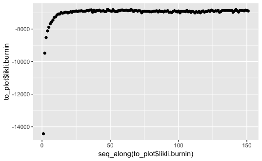

```r
to_plot<-as.data.frame(likli.burnin)
p7<-qplot(seq_along(to_plot$likli.burnin), to_plot$likli.burnin)
p7
```

# 5 Testing

```r
##Y.new<- Y.new + (Miu-Miu.new)##
###Attention!: THis line should be removed!!! Because we only scale once
# Y <- scale(Y, center = TRUE, scale = TRUE)
# #Y.new<- scale(Y.new, center=TRUE,scale=TRUE)
#
# momentmatching<-function(x.new,x){
# if (ncol(x)!=ncol(x.new)){
#   return (print("The matrixes don't have the same number of columns"))
# }else{
#   delta<-colMeans(x)-colMeans(x.new)
#   for (i in 1:ncol(x.new)){
#     x.new[,i]<-x.new[,i]+delta[i]
#   }
#   return(x.new)
# }
# }
# ##Momentum matching##
# Y.new.prime<-momentmatching(Y.new,Y)
# obj <- scale(Y, center = TRUE, scale = TRUE)
# Y.new.prime.scaled<-  scale(Y.new.prime,center = attr(obj,"scaled:center"), scale = (attr(obj,"scaled:scale")))

##Scaling##

####object created to scale the test set afterwards####
#Y.momentum.scaled <- scale(Y.new.prime, center = TRUE, scale = TRUE)
```

## 5.1 Plot results from testing

```r
logrank.new <- survdiff(smod.new ~ c.sbc.new)
#df= Degrees of freedom should be number of clusters-1
pval.new<-1 - pchisq(unlist(logrank.new)$chisq,df =length(logrank.new$n)-1)
surv.fit <- survfit(smod.new ~ c.sbc.new)
p5.new <- ggsurv(surv.fit,surv.col=c("#b16ed3","#d37f6e","#90d36e","#6ec2d3") ,plot.cens=FALSE,main = " DPMM \n Kaplan Meier Estimators \n Test Set")+ ggplot2::guides(linetype = FALSE)+labs(subtitle = paste("P-value:",toString(round(pval.new,digits = 5))))
par(mfrow=c(2,1))
p4
p5.new
```

[output not shown]

```r
pc <- prcomp(Y.new,center=TRUE,scale = TRUE)
pc.pred <- predict(pc,newdata = Y.new)
p4.new <- ggplot(as.data.frame(pc.pred), aes(x=pc.pred[,1], y= pc.pred[,2], colour= as.factor(c.sbc.new))) + ggtitle(" SBC Clustering \n TCGA-GBM Test Set") + geom_point(shape=19) + labs(y = "PC1", x = "PC2", colour = "Classes")+scale_color_manual(values=c("#b16ed3","#d37f6e","#90d36e","#6ec2d3"))
p4.new
```

[output not shown]

```r
table(c.sbc) %>%
  kable(caption = "Clusters for the training set") %>%
  kable_styling(bootstrap_options = c("striped", "hover", "condensed","responsive"),full_width = T, position = "center")
```

Clusters for the training set

| c.sbc | Freq |
| --- | --- |
| 1 | 20 |
| 2 | 11 |
| 3 | 124 |
| 4 | 5 |

```r
table(c.sbc.new) %>%
  kable(caption = "Clusters for the testing set") %>%
  kable_styling(bootstrap_options = c("striped", "hover", "condensed","responsive"),full_width = T, position = "center")
```

Clusters for the testing set

| c.sbc.new | Freq |
| --- | --- |
| 1 | 20 |
| 2 | 8 |
| 3 | 231 |
| 4 | 2 |

```r
Methods<-c("Flexmix","K-Means + Penalized Cox","SBC + AFT","SBC")
recovCIndex<-round(c(recovCIndex.flx,recovCIndex.km.pcox,max(recovCIndex.sbc.paft),max(recovCIndex.sbc)),digits = 3)
predCIndex<-round(c(predCIndex.flx,predCIndex.kk.pcox,predCIndex.sbc.aft,max(predCIndex.sbc)),digits=3)
sbc_and_comparisons<-as.data.frame(Methods)
sbc_and_comparisons$recovCIndex<-recovCIndex
sbc_and_comparisons$predCIndex<-predCIndex
sbc_and_comparisons %>%
  kable(caption = "SBC vs other methods") %>%
  kable_styling(bootstrap_options = c("striped", "hover", "condensed","responsive"), position = "center",full_width = FALSE ) %>%
  save_kable("comparisons.png")
```